# Entendimiento de las relaciones filogenética de los microorganismos reductores y oxidadores de sulfuro

María José Pino & Amalia Munera

18/4/2022

## Introducción

La idea de que la vida se restringe a un rango estrecho de temperatura, presión, acidez, alcalinidad, salinidad, u otras características ambientales ha sido desmentida desde que los microbiólogos empezaron a buscar microorganismos interesantes y otras formas de vida, y lograron aislarlos no sólo de ambientes moderados. La naturaleza contiene múltiples ambientes extremos, como las aguas termales o ácidas, lagos salinos, desiertos, lagos alcalinos y el fondo del océano.

Los descubrimientos progresivos en los últimos años en ambientes controlados por estas y otras condiciones extremas como la radiación, la hiperacidez y la salinidad, la contaminación intensa o la muy baja disponibilidad de nutrientes, ha revelado que los organismos extremófilos son abundantes y diversos.

Además, los seres humanos siempre hemos sido muy antropocéntricos en nuestro pensamiento y nuestra concepción de la vida tanto en la tierra como en el universo. Tenemos como tarea conservar los organismos extremófilos en beneficio de la humanidad y el ecosistema, ya que encontrar nuevas formas de vida contribuirá al desarrollo de la ciencia básica y nuevas tecnologías.

## Pregunta Investigación

¿Las diferencias metabólicas de los microorganismos partícipes en el ciclo del sulfuro están evidenciadas en sus relaciones filogenéticas?

## Metodología

Con base en la literatura se seleccionaron un total de 17 géneros y una especie de microorganismos reductores y oxidadores de sulfuro (13 reductores y 5 oxidadores). Para cada uno de estos organismos, se descargó la secuencia del gen 16s por medio de la plataforma de NCBI. A continuación los números de acceso para cada uno:

| Organismo | Número de acceso |
| --- | --- |
| Thiobacillus sp | X97534.1 |
| Achromatium sp | MN990460.1 |
| Begiatoa sp | AF064543.1 |
| Thiovulum sp | AH003133.2 |
| Sulfurimonas sp | MF563476.1 |
| Geovibrio sp | KJ877729.1 |
| Dethiosulfovibrio sp | KT799836.2 |
| Aquifex sp | KY483456.1 |
| Ammonifex sp | JX073595.1 |
| Desulfitobacterium sp | X81032.1 |
| Shewanella sp | OM319583.1 |
| Sulfurospirillum sp | LC379579.1 |
| Wolinella sp | DQ017139.1 |
| Geobacter sp | MW063652.1 |
| Desulfurella sp | MT022217.1 |
| Pelobacter sp | AJ296616.1 |
| Desulfofuromonas sp | M80618.1 |
| *Pseudomonas mendocina* | L28162.1 |

Para obtener cada uno de los organismos se descargó el archivo FASTA con la secuencia de 16S y fueron almacenadas en una misma carpeta. Teniendo todas las secuencias, se corrió el comando para reunirlas en un mismo archivo.

```
 cat *.fasta > sequence_16s.fa
```

Posteriormente para poder realizar los análisis filogenéticos se corrieron los siguientes comandos para así instalar los paquetes necesarios.

```
conda install -c bioconda raxml
conda install -c bioconda modeltest-ng
conda install -c bioconda raxml-ng
```

Una vez se terminó la instalación de los paquetes, se comenzó con el alineamiento de las secuencias, esto se realizó utilizando el paquete mafft de la siguiente forma:

```
mafft --thread 4 sequence_16s.fa > 16s_alignment.fa
```

Posteriormente se utilizó el paquete modeltest-ng para poder observar el modelo más propicio para realiar el análisis filogenético, de acuerdo con los resultados se decidió utilizar el modelo GTR+G4

```
modeltest-ng -i 16s_alignment.fa -d nt -o model_16s.txt

Partition 1/1:
                         Model         Score        Weight
----------------------------------------------------------
       BIC             TIM3+G4    24923.6707        0.6414
       AIC              GTR+G4    24697.0829        0.8751
      AICc              GTR+G4    24699.0829        0.8751
```

Se coninuó obteniendo el primer análisis filogenético, este se obtuvo por medio del paquete raxml-ng que nos permite obtener árboles a partir de *Maximum Likelihood*. Para este las únicas indicaciones que se dieron fue el modelo que se debe usar.

```
raxml-ng --msa 16s_alignment.fa --model GTR+G4
```

A continuación, se realizó un segundo análisis filogenético por *Maximum Likelihood* con el paquete raxmlHPC. En este se utilizó un mayor número de especificaciones mostradas a continuación

```
raxmlHPC -f a -x 1000 -#100 -k -m GTRCAT -p 50000  -s 16s_alignment.fa -n 16s_tree1
```

Para la último árbol filogenético se utilizó la herramienta de Mr.Bayes en Geneious debido auqe desde la terminal se presentaron problemas.

Finalmente, los dos árboles filógenéticos de *Maximum Likelihood* fueron observados en Geneious para así analizar los resultados.

## Resultados y discusión

Como se observó en la metodología, al momento de la selcción con base en la literatura, se obtuvieron un mayor número de organismos reductores en comparación con los oxidadores, a pesar de esto, se observó una tendencia de agrupación de acuerdo al metabolismo entre los microorganismos más cercanos, sin embargo, no se observó una tendencia en la que ambos grupos tuvieran una separación filogenética. Esto se puede ver en las tres filogénias obtenidas.

Para dar respuesta a nuestra pregunta de investigación, los análisis filogenéticos realizados muestran una evidencia de la cercanía evolutiva de los hábitos metabólicos de los organismos, a pesar de esto, no se pudo observar una formación de grupos monofiléticos de acuerdo a estas tendencias.

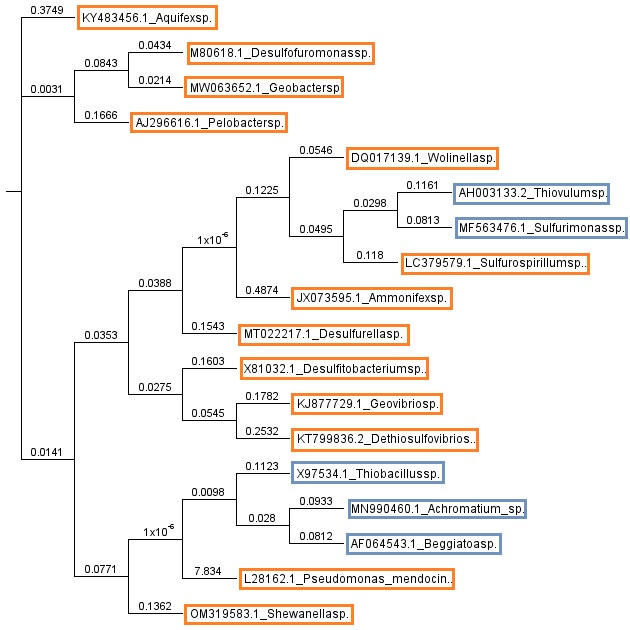

**Figura 1**. Árbol filógenetico obtenido por medio del paquete raxml-ng. Naranja: microorganismos reductores de sulfato. Azul: microorganismos oxidadores de sulfato.

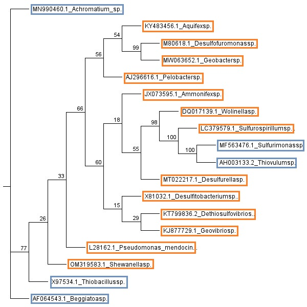

**Figura 2**. Árbol filógenetico obtenido por medio del paquete raxml (NPG). Naranja: microorganismos reductores de sulfato. Azul: microorganismos oxidadores de sulfato.

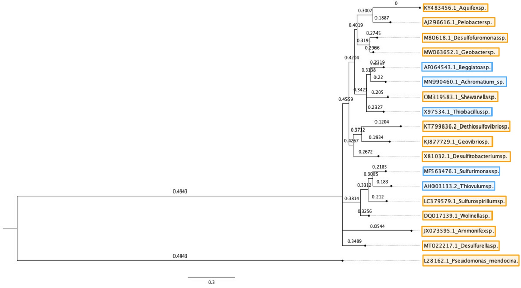

**Figura 3**. Árbol filógenetico obtenido por Mr. Bayes. Naranja: microorganismos reductores de sulfato. Azul: microorganismos oxidadores de sulfato.

## Conclusiones

*1.* Es necesario realizar más estudios filogenéticos que nos permitan entender si las relaciones evolutivas se ven afectadas por las tendencias metabolicas de los microroganismos respecto al sulfuro.

*2.* Se pudo realizar de forma exitosa un análisis filogenético que nos permitiera entender las relaciones evolutivas presenten entre organismos reductores y oxidadores del sulfuro.

*3.* Se debe continuar el estudio de este tipo de microorganimos debido a que la información presente en literatura es escaza y es necesario conocer estas tendencia para así poder reconocer la diversidad de microorganismos que podemos encontrar en un ecosistema.

## Referencias

Mardigan, M. T., Martinko, J. M., Bender, K. S., Buckley, D. H., & Stahl, D. A. (2015). Brock Biology of Microorganisms (14th ed.). Pearson. https://doi.org/10.1017/cbo9780511549984.016